# DATA 606: Final Project

Puja Roy

5/10/24

### Introduction

I leveraged the Drug Use by Age dataset from FiveThirtyEight https://github.com/fivethirtyeight/data. The reason I chose this dataset is because many people are addicted to drugs ranging from multiple ages and I wanted to explore which ages and what types of drugs certain people are addicted to.

### Abstract

This final project utilizes the “Drug Use by Age” dataset from FiveThirtyEight to explore the relationship between age and drug use. The primary research question investigates how drug use varies by age and identifies significant trends and patterns for specific substances. The dataset comprises survey data from the National Survey on Drug Use and Health, covering 17 distinct age groups ranging from 12 to 65+. The study is observational, with age as the independent variable and the percentage of users for various drugs as the dependent variables.

Using linear regression models, I analyzed the use of substances such as crack, alcohol, and heroin across different age groups. Each model revealed a straight line of best fit, indicating linear relationships between age and drug use for these substances. The analysis provided insights into how the propensity for drug use changes with age, highlighting significant relationships where appropriate.

By examining these patterns, the study aims to enhance understanding of drug addiction across age demographics, providing valuable information for public health strategies and interventions. The data and findings underscore the importance of age-specific approaches in addressing substance abuse.

```r
#install.packages("DT")
library(DT)
library(tidyverse)
library(openintro)
library(dplyr)
library(tidyr)
library(psych)
```

```r
library(ggplot2)
```

### Load the Data

```r
# Load the data
drug_data <- read.csv("https://raw.githubusercontent.com/fivethirtyeight/data/master/drug-use-by-age/drug-use-by-age.csv")

# View the structure of the data
str(drug_data)
```

```
## 'data.frame':    17 obs. of  28 variables:
##  $ age                    : chr  "12" "13" "14" "15" ...
##  $ n                      : int  2798 2757 2792 2956 3058 3038 2469 2223 2271 2354 ...
##  $ alcohol_use            : num  3.9 8.5 18.1 29.2 40.1 49.3 58.7 64.6 69.7 83.2 ...
##  $ alcohol_frequency      : num  3 6 5 6 10 13 24 36 48 52 ...
##  $ marijuana_use          : num  1.1 3.4 8.7 14.5 22.5 28 33.7 33.4 34 33 ...
##  $ marijuana_frequency    : num  4 15 24 25 30 36 52 60 60 52 ...
##  $ cocaine_use            : num  0.1 0.1 0.1 0.5 1 2 3.2 4.1 4.9 4.8 ...
##  $ cocaine_frequency      : chr  "5.0" "1.0" "5.5" "4.0" ...
##  $ crack_use              : num  0 0 0 0.1 0 0.1 0.4 0.5 0.6 0.5 ...
##  $ crack_frequency        : chr  "-" "3.0" "-" "9.5" ...
##  $ heroin_use             : num  0.1 0 0.1 0.2 0.1 0.1 0.4 0.5 0.9 0.6 ...
##  $ heroin_frequency       : chr  "35.5" "-" "2.0" "1.0" ...
##  $ hallucinogen_use       : num  0.2 0.6 1.6 2.1 3.4 4.8 7 8.6 7.4 6.3 ...
##  $ hallucinogen_frequency : num  52 6 3 4 3 3 4 3 2 4 ...
##  $ inhalant_use           : num  1.6 2.5 2.6 2.5 3 2 1.8 1.4 1.5 1.4 ...
##  $ inhalant_frequency     : chr  "19.0" "12.0" "5.0" "5.5" ...
##  $ pain_releiver_use      : num  2 2.4 3.9 5.5 6.2 8.5 9.2 9.4 10 9 ...
##  $ pain_releiver_frequency: num  36 14 12 10 7 9 12 12 10 15 ...
##  $ oxycontin_use          : num  0.1 0.1 0.4 0.8 1.1 1.4 1.7 1.5 1.7 1.3 ...
##  $ oxycontin_frequency    : chr  "24.5" "41.0" "4.5" "3.0" ...
##  $ tranquilizer_use       : num  0.2 0.3 0.9 2 2.4 3.5 4.9 4.2 5.4 3.9 ...
##  $ tranquilizer_frequency : num  52 25.5 5 4.5 11 7 12 4.5 10 7 ...
##  $ stimulant_use          : num  0.2 0.3 0.8 1.5 1.8 2.8 3 3.3 4 4.1 ...
##  $ stimulant_frequency    : num  2 4 12 6 9.5 9 8 6 12 10 ...
##  $ meth_use               : num  0 0.1 0.1 0.3 0.3 0.6 0.5 0.4 0.9 0.6 ...
##  $ meth_frequency         : chr  "-" "5.0" "24.0" "10.5" ...
##  $ sedative_use           : num  0.2 0.1 0.2 0.4 0.2 0.5 0.4 0.3 0.5 0.3 ...
##  $ sedative_frequency     : num  13 19 16.5 30 3 6.5 10 6 4 9 ...
```

```r
# Remove NA values
clean_drug_data <- na.omit(drug_data)
```

```r
# View the structure of the cleaned data
str(clean_drug_data)
```

```
## 'data.frame':    17 obs. of  28 variables:
##  $ age                    : chr  "12" "13" "14" "15" ...
##  $ n                      : int  2798 2757 2792 2956 3058 3038 2469 2223 2271 2354 ...
##  $ alcohol_use            : num  3.9 8.5 18.1 29.2 40.1 49.3 58.7 64.6 69.7 83.2 ...
##  $ alcohol_frequency      : num  3 6 5 6 10 13 24 36 48 52 ...
##  $ marijuana_use          : num  1.1 3.4 8.7 14.5 22.5 28 33.7 33.4 34 33 ...
##  $ marijuana_frequency    : num  4 15 24 25 30 36 52 60 60 52 ...
##  $ cocaine_use            : num  0.1 0.1 0.1 0.5 1 2 3.2 4.1 4.9 4.8 ...
##  $ cocaine_frequency      : chr  "5.0" "1.0" "5.5" "4.0" ...
##  $ crack_use              : num  0 0 0 0.1 0 0.1 0.4 0.5 0.6 0.5 ...
##  $ crack_frequency        : chr  "-" "3.0" "-" "9.5" ...
##  $ heroin_use             : num  0.1 0 0.1 0.2 0.1 0.1 0.4 0.5 0.9 0.6 ...
##  $ heroin_frequency       : chr  "35.5" "-" "2.0" "1.0" ...
##  $ hallucinogen_use       : num  0.2 0.6 1.6 2.1 3.4 4.8 7 8.6 7.4 6.3 ...
##  $ hallucinogen_frequency : num  52 6 3 4 3 3 4 3 2 4 ...
##  $ inhalant_use           : num  1.6 2.5 2.6 2.5 3 2 1.8 1.4 1.5 1.4 ...
##  $ inhalant_frequency     : chr  "19.0" "12.0" "5.0" "5.5" ...
##  $ pain_releiver_use      : num  2 2.4 3.9 5.5 6.2 8.5 9.2 9.4 10 9 ...
##  $ pain_releiver_frequency: num  36 14 12 10 7 9 12 12 10 15 ...
##  $ oxycontin_use          : num  0.1 0.1 0.4 0.8 1.1 1.4 1.7 1.5 1.7 1.3 ...
##  $ oxycontin_frequency    : chr  "24.5" "41.0" "4.5" "3.0" ...
##  $ tranquilizer_use       : num  0.2 0.3 0.9 2 2.4 3.5 4.9 4.2 5.4 3.9 ...
##  $ tranquilizer_frequency : num  52 25.5 5 4.5 11 7 12 4.5 10 7 ...
##  $ stimulant_use          : num  0.2 0.3 0.8 1.5 1.8 2.8 3 3.3 4 4.1 ...
##  $ stimulant_frequency    : num  2 4 12 6 9.5 9 8 6 12 10 ...
##  $ meth_use               : num  0 0.1 0.1 0.3 0.3 0.6 0.5 0.4 0.9 0.6 ...
##  $ meth_frequency         : chr  "-" "5.0" "24.0" "10.5" ...
##  $ sedative_use           : num  0.2 0.1 0.2 0.4 0.2 0.5 0.4 0.3 0.5 0.3 ...
##  $ sedative_frequency     : num  13 19 16.5 30 3 6.5 10 6 4 9 ...
```

```r
# Summary statistics for the cleaned data
summary(clean_drug_data)
```

```
##      age                  n         alcohol_use    alcohol_frequency
##  Length:17          Min.   :2223   Min.   : 3.90   Min.   : 3.00
##  Class :character   1st Qu.:2469   1st Qu.:40.10   1st Qu.:10.00
##  Mode  :character   Median :2798   Median :64.60   Median :48.00
##                     Mean   :3251   Mean   :55.43   Mean   :33.35
##                     3rd Qu.:3058   3rd Qu.:77.50   3rd Qu.:52.00
##                     Max.   :7391   Max.   :84.20   Max.   :52.00
##  marijuana_use   marijuana_frequency  cocaine_use    cocaine_frequency
##  Min.   : 1.10   Min.   : 4.00       Min.   :0.000   Length:17
##  1st Qu.: 8.70   1st Qu.:30.00       1st Qu.:0.500   Class :character
##  Median :20.80   Median :52.00       Median :2.000   Mode  :character
##  Mean   :18.92   Mean   :42.94       Mean   :2.176
##  3rd Qu.:28.40   3rd Qu.:52.00       3rd Qu.:4.000
##  Max.   :34.00   Max.   :72.00       Max.   :4.900
##    crack_use      crack_frequency      heroin_use     heroin_frequency
##  Min.   :0.0000   Length:17          Min.   :0.0000   Length:17
##  1st Qu.:0.0000   Class :character   1st Qu.:0.1000   Class :character
##  Median :0.4000   Mode  :character   Median :0.2000   Mode  :character
##  Mean   :0.2941                      Mean   :0.3529
##  3rd Qu.:0.5000                      3rd Qu.:0.6000
##  Max.   :0.6000                      Max.   :1.1000
##  hallucinogen_use hallucinogen_frequency  inhalant_use   inhalant_frequency
##  Min.   :0.100    Min.   : 2.000         Min.   :0.000   Length:17
##  1st Qu.:0.600    1st Qu.: 3.000         1st Qu.:0.600   Class :character
##  Median :3.200    Median : 3.000         Median :1.400   Mode  :character
##  Mean   :3.394    Mean   : 8.412         Mean   :1.388
##  3rd Qu.:5.200    3rd Qu.: 4.000         3rd Qu.:2.000
##  Max.   :8.600    Max.   :52.000         Max.   :3.000
##  pain_releiver_use pain_releiver_frequency oxycontin_use    oxycontin_frequency
##  Min.   : 0.600    Min.   : 7.00           Min.   :0.0000   Length:17
##  1st Qu.: 3.900    1st Qu.:12.00           1st Qu.:0.4000   Class :character
##  Median : 6.200    Median :12.00           Median :1.1000   Mode  :character
##  Mean   : 6.271    Mean   :14.71           Mean   :0.9353
##  3rd Qu.: 9.000    3rd Qu.:15.00           3rd Qu.:1.4000
##  Max.   :10.000    Max.   :36.00           Max.   :1.7000
##  tranquilizer_use tranquilizer_frequency stimulant_use   stimulant_frequency
##  Min.   :0.200    Min.   : 4.50          Min.   :0.000   Min.   :  2.00
##  1st Qu.:1.400    1st Qu.: 6.00          1st Qu.:0.600   1st Qu.:  7.00
##  Median :3.500    Median :10.00          Median :1.800   Median : 10.00
##  Mean   :2.806    Mean   :11.74          Mean   :1.918   Mean   : 31.15
##  3rd Qu.:4.200    3rd Qu.:11.00          3rd Qu.:3.000   3rd Qu.: 12.00
##  Max.   :5.400    Max.   :52.00          Max.   :4.100   Max.   :364.00
##     meth_use      meth_frequency      sedative_use    sedative_frequency
##  Min.   :0.0000   Length:17          Min.   :0.0000   Min.   :  3.00
##  1st Qu.:0.2000   Class :character   1st Qu.:0.2000   1st Qu.:  6.50
##  Median :0.4000   Mode  :character   Median :0.3000   Median : 10.00
##  Mean   :0.3824                      Mean   :0.2824   Mean   : 19.38
##  3rd Qu.:0.6000                      3rd Qu.:0.4000   3rd Qu.: 17.50
##  Max.   :0.9000                      Max.   :0.5000   Max.   :104.00
```

```r
# Summary statistics for quantitative variables
describe(clean_drug_data)
```

```
##                         vars  n    mean      sd median trimmed    mad    min
## age*                       1 17    9.00    5.05    9.0    9.00   5.93    1.0
## n                          2 17 3251.06 1297.89 2798.0 3043.60 487.78 2223.0
## alcohol_use                3 17   55.43   26.88   64.6   56.95  23.87    3.9
## alcohol_frequency          4 17   33.35   21.32   48.0   34.13   5.93    3.0
## marijuana_use              5 17   18.92   11.96   20.8   19.11  17.94    1.1
## marijuana_frequency        6 17   42.94   18.36   52.0   43.60  11.86    4.0
## cocaine_use                7 17    2.18    1.82    2.0    2.14   2.82    0.0
## cocaine_frequency*         8 17    6.00    2.52    6.0    6.07   1.48    1.0
## crack_use                  9 17    0.29    0.24    0.4    0.29   0.15    0.0
## crack_frequency*          10 17    6.71    4.16    7.0    6.67   5.93    1.0
## heroin_use                11 17    0.35    0.33    0.2    0.33   0.30    0.0
## heroin_frequency*         12 17    9.00    5.05    9.0    9.00   5.93    1.0
## hallucinogen_use          13 17    3.39    2.79    3.2    3.27   3.85    0.1
## hallucinogen_frequency    14 17    8.41   15.00    3.0    5.93   1.48    2.0
## inhalant_use              15 17    1.39    0.93    1.4    1.37   1.19    0.0
## inhalant_frequency*       16 17    6.76    2.93    7.0    6.87   2.97    1.0
## pain_releiver_use         17 17    6.27    3.17    6.2    6.40   4.15    0.6
## pain_releiver_frequency   18 17   14.71    6.94   12.0   13.80   2.97    7.0
## oxycontin_use             19 17    0.94    0.61    1.1    0.95   0.89    0.0
## oxycontin_frequency*      20 17    7.35    4.57    7.0    7.27   5.93    1.0
## tranquilizer_use          21 17    2.81    1.75    3.5    2.81   2.08    0.2
## tranquilizer_frequency    22 17   11.74   11.49   10.0    9.53   4.45    4.5
## stimulant_use             23 17    1.92    1.41    1.8    1.90   1.78    0.0
## stimulant_frequency       24 17   31.15   85.97   10.0   10.90   2.97    2.0
## meth_use                  25 17    0.38    0.26    0.4    0.37   0.30    0.0
## meth_frequency*           26 17    7.06    4.15    7.0    7.00   4.45    1.0
## sedative_use              27 17    0.28    0.14    0.3    0.29   0.15    0.0
## sedative_frequency        28 17   19.38   24.83   10.0   14.83   8.90    3.0
##                            max  range  skew kurtosis     se
## age*                      17.0   16.0  0.00    -1.41   1.22
## n                       7391.0 5168.0  1.95     3.33 314.78
## alcohol_use               84.2   80.3 -0.63    -1.07   6.52
## alcohol_frequency         52.0   49.0 -0.36    -1.83   5.17
## marijuana_use             34.0   32.9 -0.14    -1.59   2.90
## marijuana_frequency       72.0   68.0 -0.50    -0.84   4.45
## cocaine_use                4.9    4.9  0.20    -1.65   0.44
## cocaine_frequency*        10.0    9.0 -0.22    -0.70   0.61
## crack_use                  0.6    0.6 -0.26    -1.85   0.06
## crack_frequency*          13.0   12.0 -0.08    -1.59   1.01
## heroin_use                 1.1    1.1  0.74    -0.73   0.08
## heroin_frequency*         17.0   16.0  0.00    -1.41   1.22
## hallucinogen_use           8.6    8.5  0.36    -1.35   0.68
## hallucinogen_frequency    52.0   50.0  2.19     3.07   3.64
## inhalant_use               3.0    3.0  0.12    -1.35   0.22
## inhalant_frequency*       11.0   10.0 -0.50    -1.04   0.71
## pain_releiver_use         10.0    9.4 -0.32    -1.51   0.77
## pain_releiver_frequency   36.0   29.0  1.74     2.64   1.68
## oxycontin_use              1.7    1.7 -0.21    -1.59   0.15
## oxycontin_frequency*      15.0   14.0  0.19    -1.48   1.11
## tranquilizer_use           5.4    5.2 -0.22    -1.53   0.43
## tranquilizer_frequency    52.0   47.5  2.56     6.05   2.79
## stimulant_use              4.1    4.1  0.10    -1.56   0.34
## stimulant_frequency      364.0  362.0  3.40    10.22  20.85
## meth_use                   0.9    0.9  0.14    -1.16   0.06
## meth_frequency*           14.0   13.0  0.06    -1.36   1.01
## sedative_use               0.5    0.5 -0.11    -0.89   0.03
## sedative_frequency       104.0  101.0  2.39     5.15   6.02
```

```r
# Summary statistics by age group
describeBy(clean_drug_data, group = drug_data$age)
```

[output not shown]

[output cut: 966 more lines]

```
## hallucinogen_frequency    NA       NA NA
## inhalant_use              NA       NA NA
## inhalant_frequency        NA       NA NA
## pain_releiver_use         NA       NA NA
## pain_releiver_frequency   NA       NA NA
## oxycontin_use             NA       NA NA
## oxycontin_frequency       NA       NA NA
## tranquilizer_use          NA       NA NA
## tranquilizer_frequency    NA       NA NA
## stimulant_use             NA       NA NA
## stimulant_frequency       NA       NA NA
## meth_use                  NA       NA NA
## meth_frequency            NA       NA NA
## sedative_use              NA       NA NA
## sedative_frequency        NA       NA NA
```

```r
# Frequency table for age group
age_table <- table(clean_drug_data$age)
print(age_table)
```

```
##
##    12    13    14    15    16    17    18    19    20    21 22-23 24-25 26-29
##     1     1     1     1     1     1     1     1     1     1     1     1     1
## 30-34 35-49 50-64   65+
##     1     1     1     1
```

```r
# Print column names
colnames(clean_drug_data)
```

```
##  [1] "age"                     "n"
##  [3] "alcohol_use"             "alcohol_frequency"
##  [5] "marijuana_use"           "marijuana_frequency"
##  [7] "cocaine_use"             "cocaine_frequency"
##  [9] "crack_use"               "crack_frequency"
## [11] "heroin_use"              "heroin_frequency"
## [13] "hallucinogen_use"        "hallucinogen_frequency"
## [15] "inhalant_use"            "inhalant_frequency"
## [17] "pain_releiver_use"       "pain_releiver_frequency"
## [19] "oxycontin_use"           "oxycontin_frequency"
## [21] "tranquilizer_use"        "tranquilizer_frequency"
## [23] "stimulant_use"           "stimulant_frequency"
## [25] "meth_use"                "meth_frequency"
## [27] "sedative_use"            "sedative_frequency"
```

### Exploratory Data Analysis (EDA)

```r
datatable(clean_drug_data)
```

|  | age | n | alcohol_use | alcohol_frequency | marijuana_use | marijuana_frequency | cocaine_use | cocaine_frequency | crack_use | crack_frequency | heroin_use | heroin_frequency | hallucinogen_use | hallucinogen_frequency | inhalant_use | inhalant_frequency | pain_releiver_use | pain_releiver_frequency | oxycontin_use | oxycontin_frequency | tranquilizer_use | tranquilizer_frequency | stimulant_use | stimulant_frequency | meth_use | meth_frequency | sedative_use | sedative_frequency |
| --- | --- | --- | --- | --- | --- | --- | --- | --- | --- | --- | --- | --- | --- | --- | --- | --- | --- | --- | --- | --- | --- | --- | --- | --- | --- | --- | --- | --- |
| 1 | 12 | 2798 | 3.9 | 3 | 1.1 | 4 | 0.1 | 5.0 | 0 | - | 0.1 | 35.5 | 0.2 | 52 | 1.6 | 19.0 | 2 | 36 | 0.1 | 24.5 | 0.2 | 52 | 0.2 | 2 | 0 | - | 0.2 | 13 |
| 2 | 13 | 2757 | 8.5 | 6 | 3.4 | 15 | 0.1 | 1.0 | 0 | 3.0 | 0 | - | 0.6 | 6 | 2.5 | 12.0 | 2.4 | 14 | 0.1 | 41.0 | 0.3 | 25.5 | 0.3 | 4 | 0.1 | 5.0 | 0.1 | 19 |
| 3 | 14 | 2792 | 18.1 | 5 | 8.7 | 24 | 0.1 | 5.5 | 0 | - | 0.1 | 2.0 | 1.6 | 3 | 2.6 | 5.0 | 3.9 | 12 | 0.4 | 4.5 | 0.9 | 5 | 0.8 | 12 | 0.1 | 24.0 | 0.2 | 16.5 |
| 4 | 15 | 2956 | 29.2 | 6 | 14.5 | 25 | 0.5 | 4.0 | 0.1 | 9.5 | 0.2 | 1.0 | 2.1 | 4 | 2.5 | 5.5 | 5.5 | 10 | 0.8 | 3.0 | 2 | 4.5 | 1.5 | 6 | 0.3 | 10.5 | 0.4 | 30 |
| 5 | 16 | 3058 | 40.1 | 10 | 22.5 | 30 | 1 | 7.0 | 0 | 1.0 | 0.1 | 66.5 | 3.4 | 3 | 3 | 3.0 | 6.2 | 7 | 1.1 | 4.0 | 2.4 | 11 | 1.8 | 9.5 | 0.3 | 36.0 | 0.2 | 3 |
| 6 | 17 | 3038 | 49.3 | 13 | 28 | 36 | 2 | 5.0 | 0.1 | 21.0 | 0.1 | 64.0 | 4.8 | 3 | 2 | 4.0 | 8.5 | 9 | 1.4 | 6.0 | 3.5 | 7 | 2.8 | 9 | 0.6 | 48.0 | 0.5 | 6.5 |
| 7 | 18 | 2469 | 58.7 | 24 | 33.7 | 52 | 3.2 | 5.0 | 0.4 | 10.0 | 0.4 | 46.0 | 7 | 4 | 1.8 | 4.0 | 9.2 | 12 | 1.7 | 7.0 | 4.9 | 12 | 3 | 8 | 0.5 | 12.0 | 0.4 | 10 |
| 8 | 19 | 2223 | 64.6 | 36 | 33.4 | 60 | 4.1 | 5.5 | 0.5 | 2.0 | 0.5 | 180.0 | 8.6 | 3 | 1.4 | 3.0 | 9.4 | 12 | 1.5 | 7.5 | 4.2 | 4.5 | 3.3 | 6 | 0.4 | 105.0 | 0.3 | 6 |
| 9 | 20 | 2271 | 69.7 | 48 | 34 | 60 | 4.9 | 8.0 | 0.6 | 5.0 | 0.9 | 45.0 | 7.4 | 2 | 1.5 | 4.0 | 10 | 10 | 1.7 | 12.0 | 5.4 | 10 | 4 | 12 | 0.9 | 12.0 | 0.5 | 4 |
| 10 | 21 | 2354 | 83.2 | 52 | 33 | 52 | 4.8 | 5.0 | 0.5 | 17.0 | 0.6 | 30.0 | 6.3 | 4 | 1.4 | 2.0 | 9 | 15 | 1.3 | 13.5 | 3.9 | 7 | 4.1 | 10 | 0.6 | 2.0 | 0.3 | 9 |

[output cut: 7 more lines]

### Data Visualizations

I used density plots to visualize the distribution of drug use percentages across different age groups. They provide a smooth, continuous representation of the data’s distribution, allowing for easier identification of patterns and trends that may not be as apparent in histograms or other types of plots.

### Density Plots

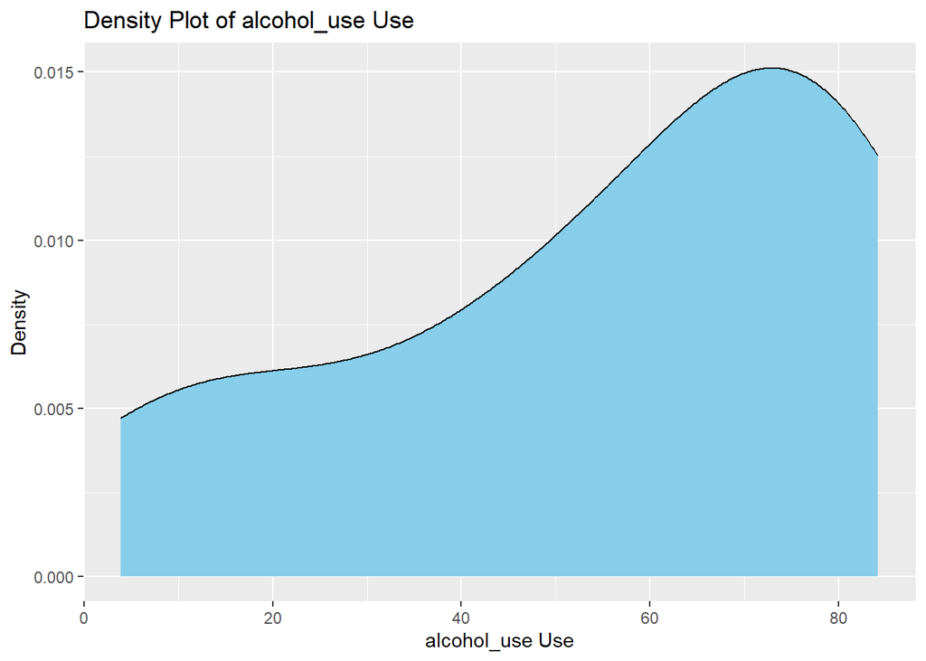

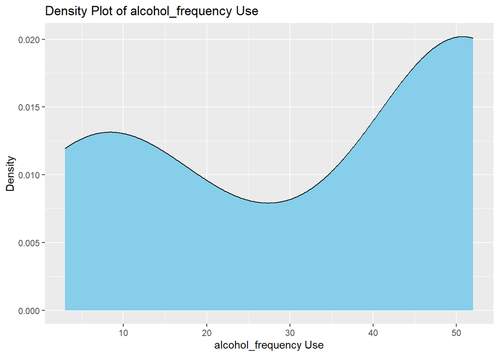

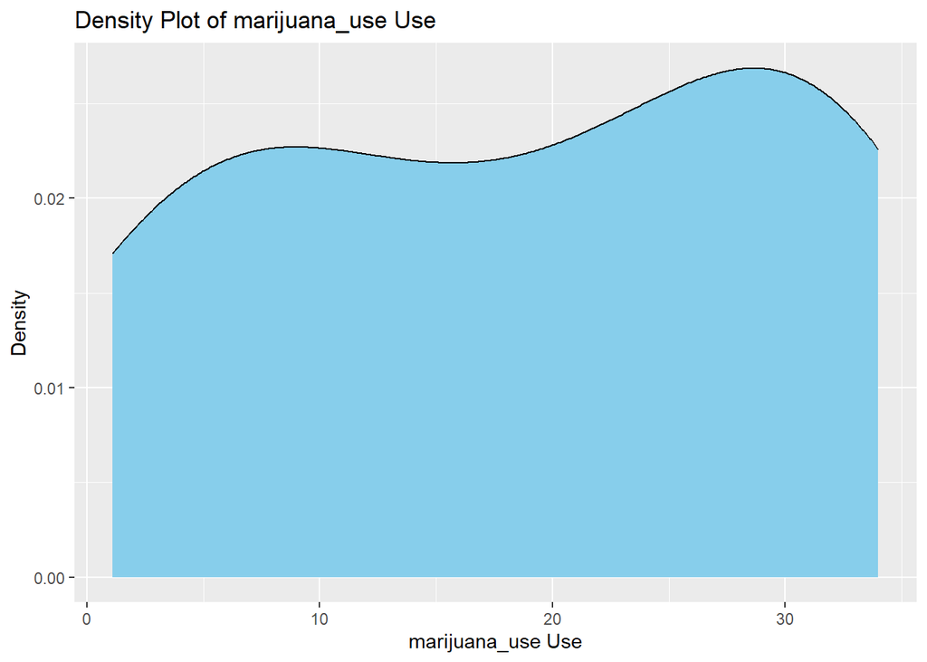

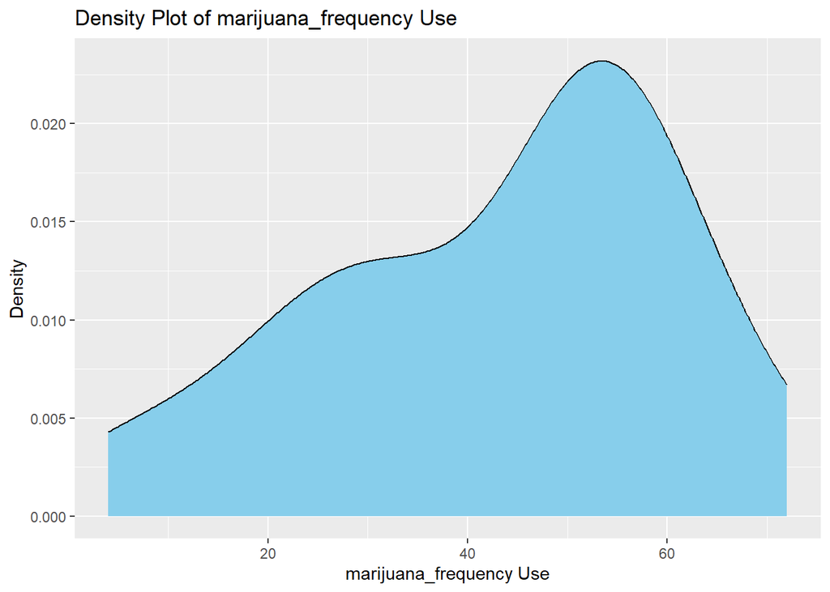

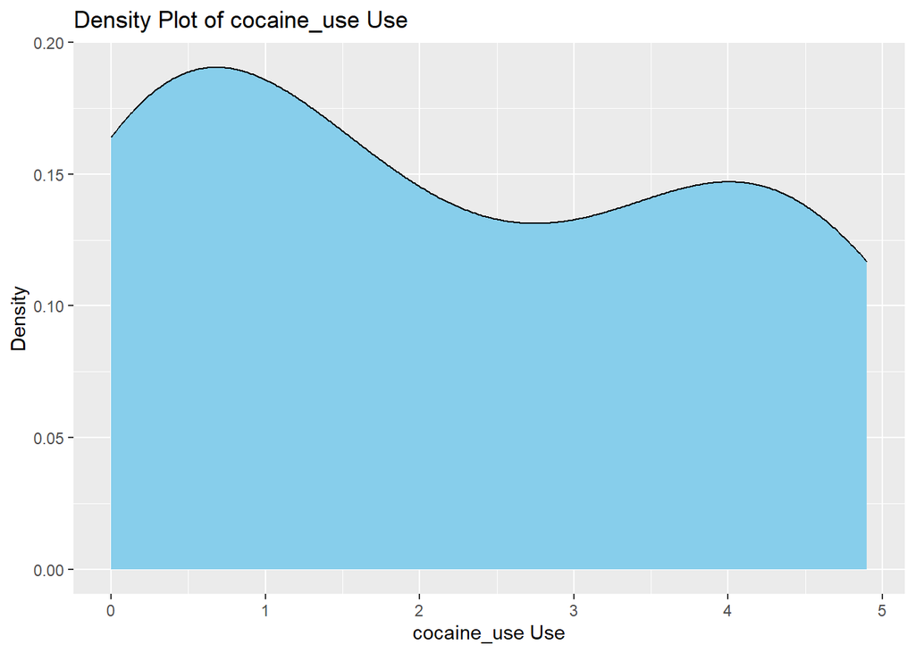

[figure not shown]

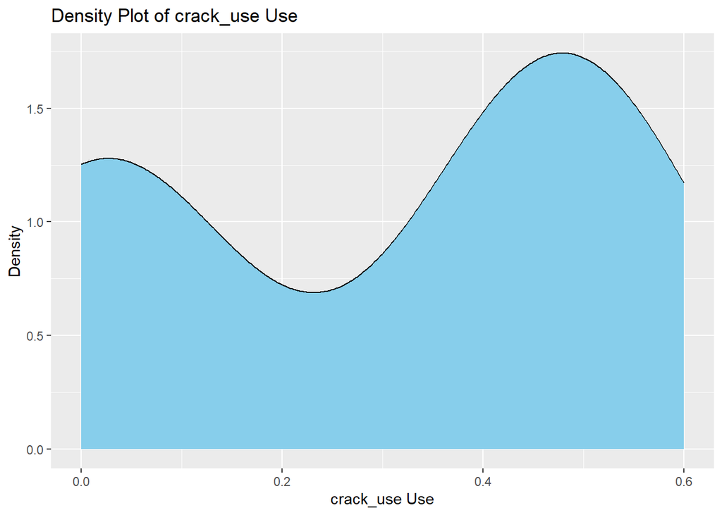

[figure not shown]

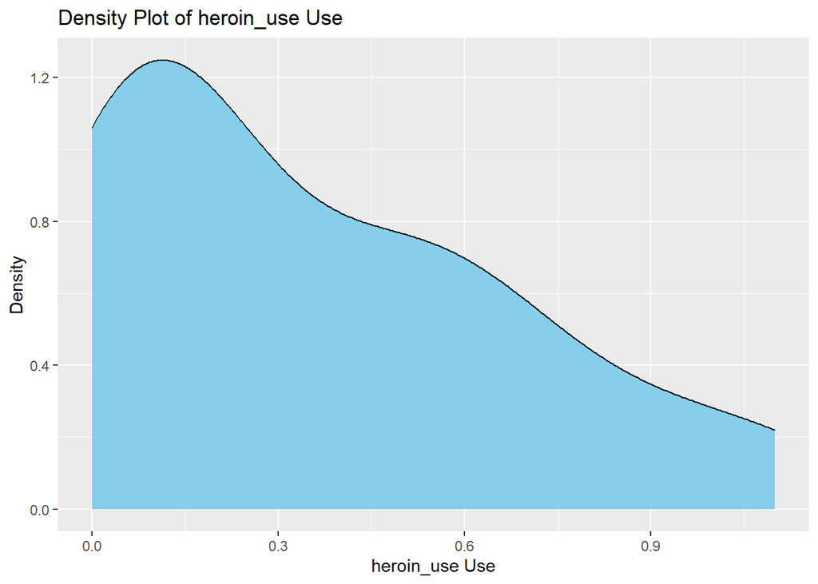

[output not shown]

[figure not shown]

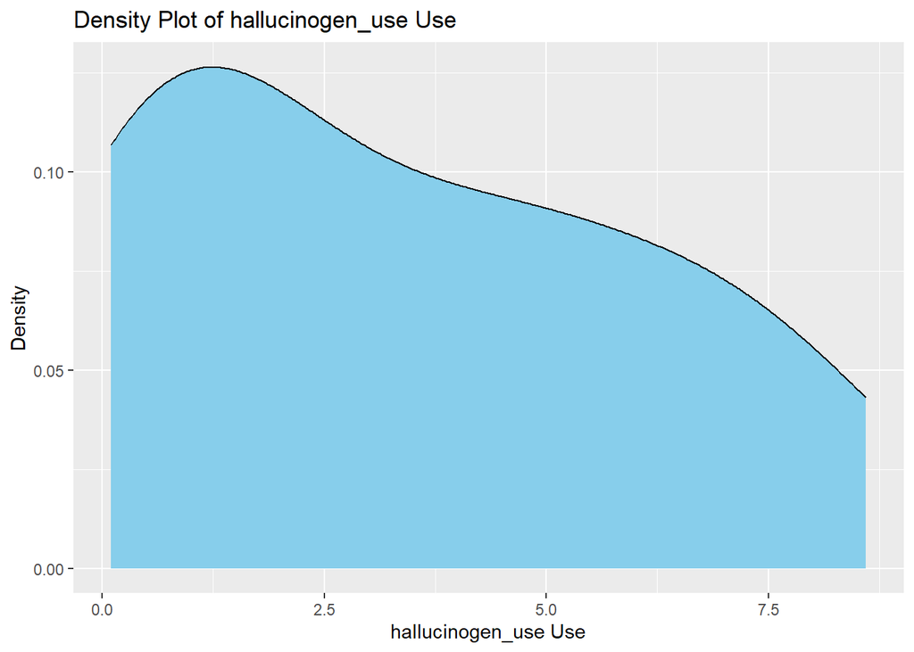

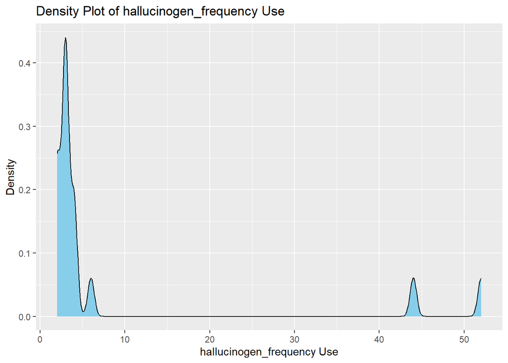

[14 more figures not shown]

```r
# Density plots for each drug
density_plots <- lapply(names(clean_drug_data)[3:ncol(clean_drug_data)], function(drug_name) {
  ggplot(clean_drug_data, aes_string(x = drug_name)) +
    geom_density(fill = "skyblue", color = "black") +
    labs(title = paste("Density Plot of", drug_name, "Use"),
         x = paste(drug_name, "Use"),
         y = "Density")
})
# Output the density plots
density_plots
```

### QQ Plots

I used QQ plots help assess the normality of the data distributions.

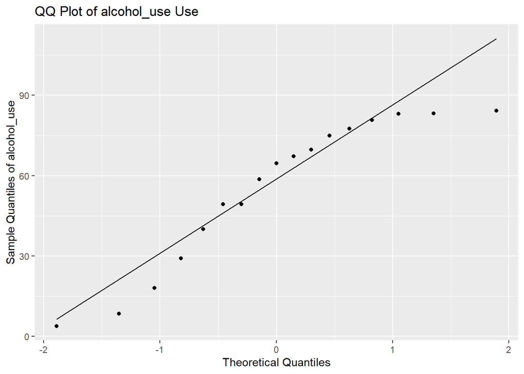

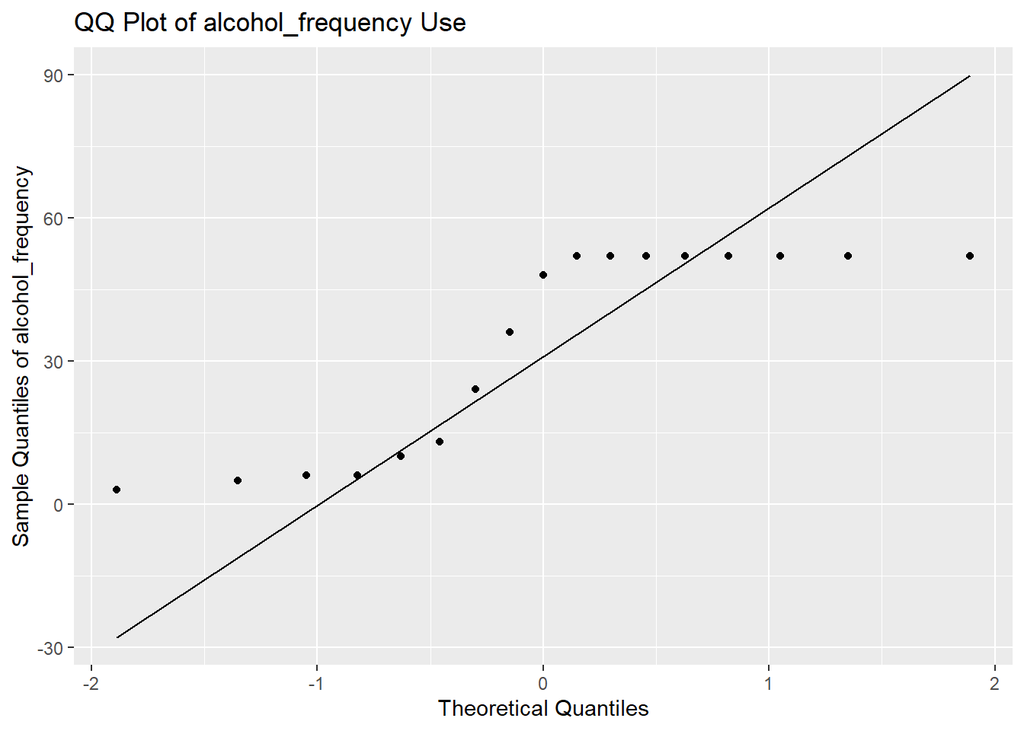

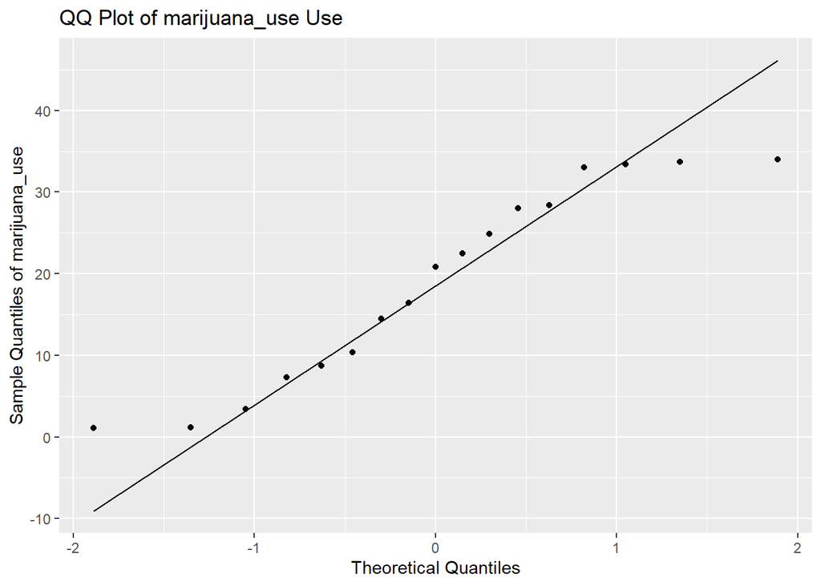

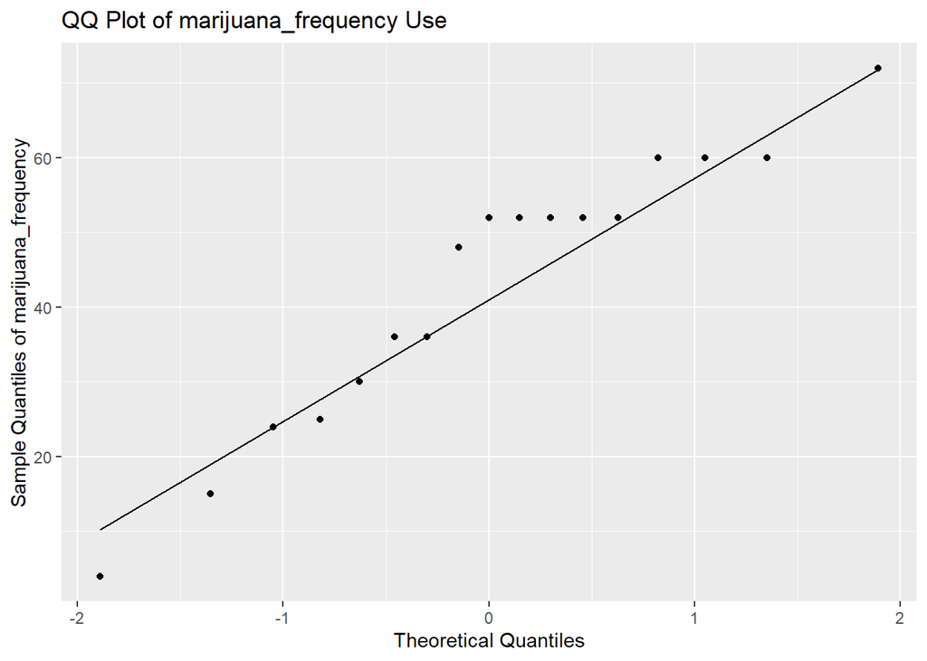

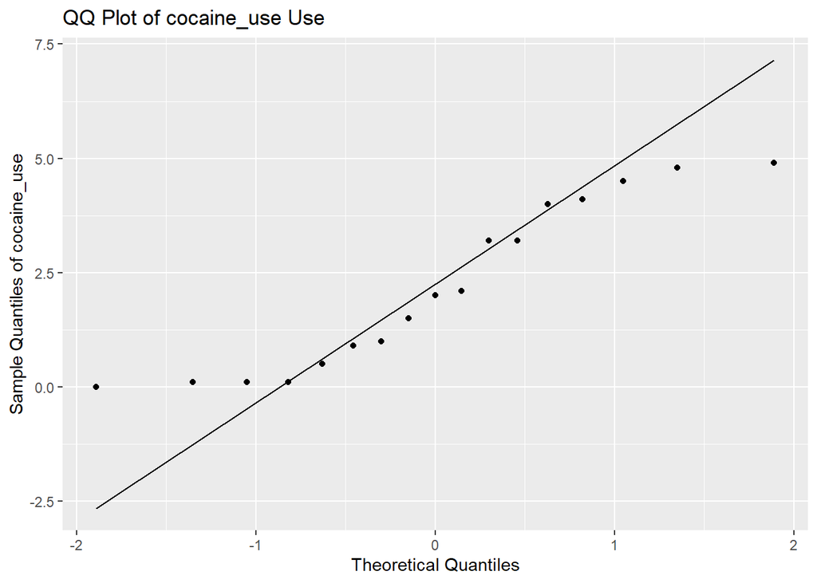

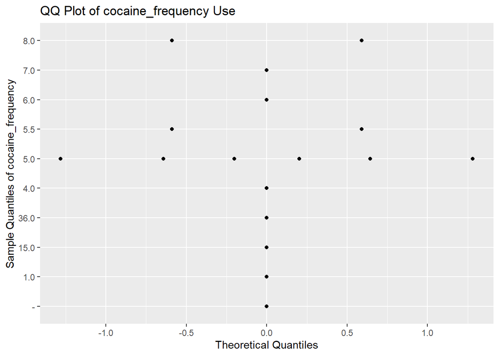

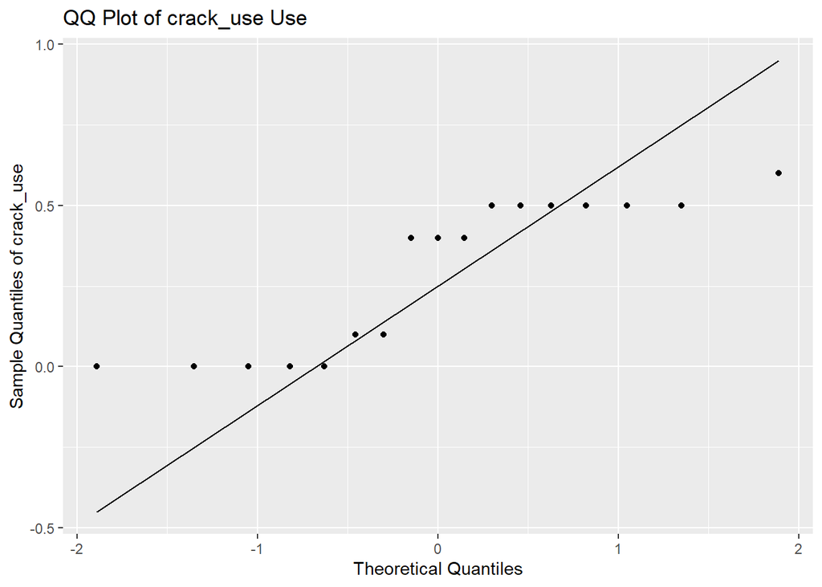

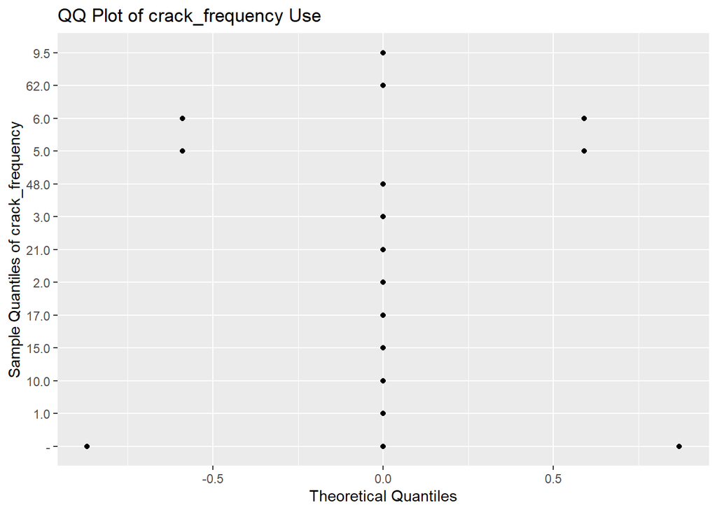

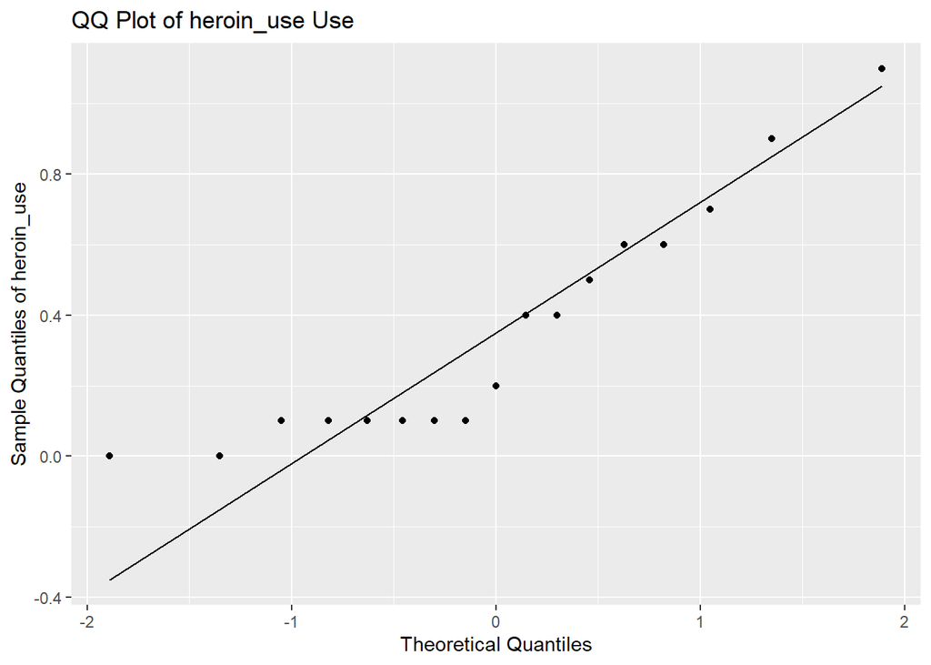

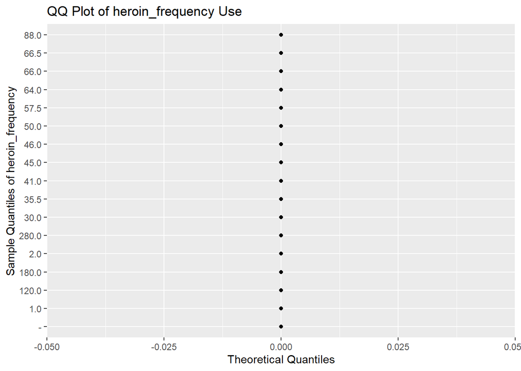

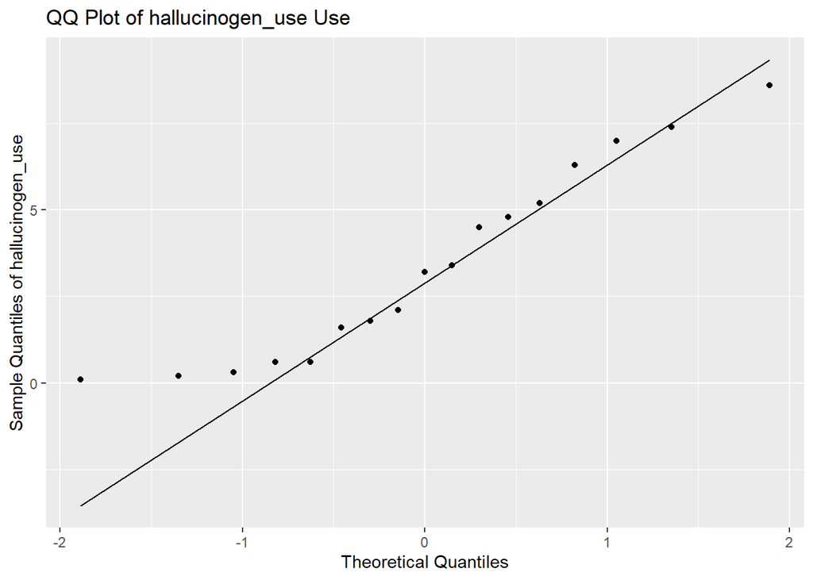

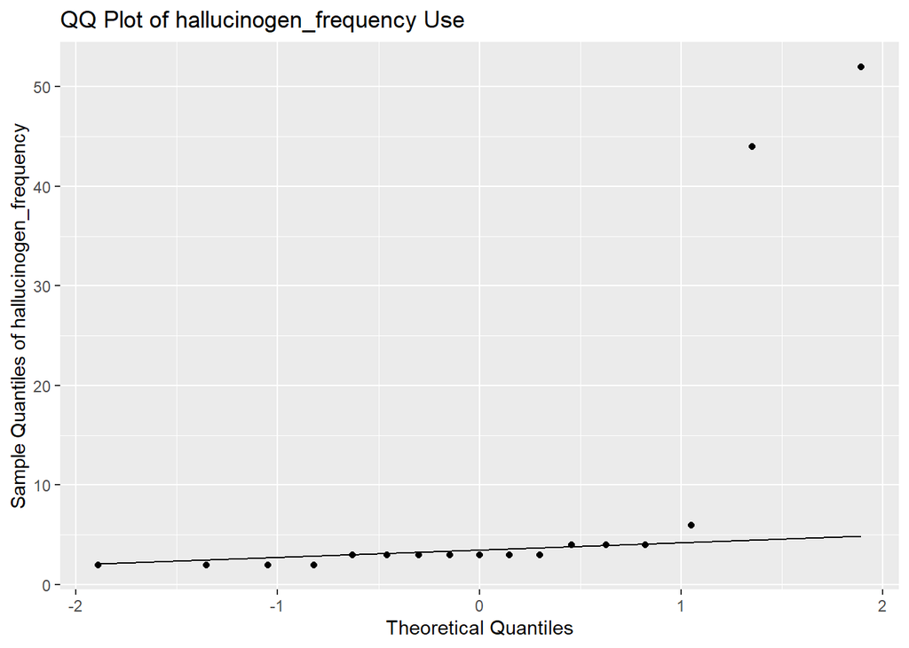

[14 more figures not shown]

```r
# QQ plots for each drug
qq_plots <- lapply(names(clean_drug_data)[3:ncol(clean_drug_data)], function(drug_name) {
  ggplot(clean_drug_data, aes_string(sample = drug_name)) +
    stat_qq() +
    stat_qq_line() +
    labs(title = paste("QQ Plot of", drug_name, "Use"),
         x = "Theoretical Quantiles",
         y = paste("Sample Quantiles of", drug_name))
})

# Output the QQ plots
qq_plots
```

### Summary Statistics

The summary statistics for each drug and age group provides insights into the typical usage patterns, the range of usage, and the presence of any outliers.

```r
# Summary statistics for each drug
summary_stats <- lapply(names(clean_drug_data)[3:ncol(clean_drug_data)], function(drug_name) {
  summary(clean_drug_data[[drug_name]])
})

# Output the summary statistics
summary_stats
```

```
## [[1]]
##    Min. 1st Qu.  Median    Mean 3rd Qu.    Max.
##    3.90   40.10   64.60   55.43   77.50   84.20
##
## [[2]]
##    Min. 1st Qu.  Median    Mean 3rd Qu.    Max.
##    3.00   10.00   48.00   33.35   52.00   52.00
##
## [[3]]
##    Min. 1st Qu.  Median    Mean 3rd Qu.    Max.
##    1.10    8.70   20.80   18.92   28.40   34.00
##
## [[4]]
##    Min. 1st Qu.  Median    Mean 3rd Qu.    Max.
##    4.00   30.00   52.00   42.94   52.00   72.00
##
## [[5]]
##    Min. 1st Qu.  Median    Mean 3rd Qu.    Max.
##   0.000   0.500   2.000   2.176   4.000   4.900
##
## [[6]]
##    Length     Class      Mode
##        17 character character
##
## [[7]]
##    Min. 1st Qu.  Median    Mean 3rd Qu.    Max.
##  0.0000  0.0000  0.4000  0.2941  0.5000  0.6000
##
## [[8]]
##    Length     Class      Mode
##        17 character character
##
## [[9]]
##    Min. 1st Qu.  Median    Mean 3rd Qu.    Max.
##  0.0000  0.1000  0.2000  0.3529  0.6000  1.1000
##
## [[10]]
##    Length     Class      Mode
##        17 character character
##
```

[output cut: 48 more lines]

```
## [[23]]
##    Min. 1st Qu.  Median    Mean 3rd Qu.    Max.
##  0.0000  0.2000  0.4000  0.3824  0.6000  0.9000
##
## [[24]]
##    Length     Class      Mode
##        17 character character
##
## [[25]]
##    Min. 1st Qu.  Median    Mean 3rd Qu.    Max.
##  0.0000  0.2000  0.3000  0.2824  0.4000  0.5000
##
## [[26]]
##    Min. 1st Qu.  Median    Mean 3rd Qu.    Max.
##    3.00    6.50   10.00   19.38   17.50  104.00
```

### Linear Regression Models

To analyze the relationship between age and drug use, I created linear regression models for various substances, including cocaine, crack, alcohol, and heroin. The linear regression model for each drug helps to understand how drug use percentage changes with age.

Cocaine Use: H0: Age has no effect on the percentage of cocaine users. H1: Age has a significant effect on the percentage of cocaine users.

```r
# Remove rows with any NA, NaN, or Inf values
clean_drug_data <- drug_data %>%
  mutate(across(everything(), ~ifelse(is.nan(.), NA, .))) %>%
  filter_all(all_vars(!is.na(.))) %>%
  filter_all(all_vars(!is.infinite(.)))

# Verify the cleaned data
summary(clean_drug_data)
```

```
##      age                  n         alcohol_use    alcohol_frequency
##  Length:17          Min.   :2223   Min.   : 3.90   Min.   : 3.00
##  Class :character   1st Qu.:2469   1st Qu.:40.10   1st Qu.:10.00
##  Mode  :character   Median :2798   Median :64.60   Median :48.00
##                     Mean   :3251   Mean   :55.43   Mean   :33.35
##                     3rd Qu.:3058   3rd Qu.:77.50   3rd Qu.:52.00
##                     Max.   :7391   Max.   :84.20   Max.   :52.00
##  marijuana_use   marijuana_frequency  cocaine_use    cocaine_frequency
##  Min.   : 1.10   Min.   : 4.00       Min.   :0.000   Length:17
##  1st Qu.: 8.70   1st Qu.:30.00       1st Qu.:0.500   Class :character
##  Median :20.80   Median :52.00       Median :2.000   Mode  :character
##  Mean   :18.92   Mean   :42.94       Mean   :2.176
##  3rd Qu.:28.40   3rd Qu.:52.00       3rd Qu.:4.000
##  Max.   :34.00   Max.   :72.00       Max.   :4.900
##    crack_use      crack_frequency      heroin_use     heroin_frequency
##  Min.   :0.0000   Length:17          Min.   :0.0000   Length:17
##  1st Qu.:0.0000   Class :character   1st Qu.:0.1000   Class :character
##  Median :0.4000   Mode  :character   Median :0.2000   Mode  :character
##  Mean   :0.2941                      Mean   :0.3529
##  3rd Qu.:0.5000                      3rd Qu.:0.6000
##  Max.   :0.6000                      Max.   :1.1000
##  hallucinogen_use hallucinogen_frequency  inhalant_use   inhalant_frequency
##  Min.   :0.100    Min.   : 2.000         Min.   :0.000   Length:17
##  1st Qu.:0.600    1st Qu.: 3.000         1st Qu.:0.600   Class :character
##  Median :3.200    Median : 3.000         Median :1.400   Mode  :character
##  Mean   :3.394    Mean   : 8.412         Mean   :1.388
##  3rd Qu.:5.200    3rd Qu.: 4.000         3rd Qu.:2.000
##  Max.   :8.600    Max.   :52.000         Max.   :3.000
##  pain_releiver_use pain_releiver_frequency oxycontin_use    oxycontin_frequency
##  Min.   : 0.600    Min.   : 7.00           Min.   :0.0000   Length:17
##  1st Qu.: 3.900    1st Qu.:12.00           1st Qu.:0.4000   Class :character
##  Median : 6.200    Median :12.00           Median :1.1000   Mode  :character
##  Mean   : 6.271    Mean   :14.71           Mean   :0.9353
##  3rd Qu.: 9.000    3rd Qu.:15.00           3rd Qu.:1.4000
##  Max.   :10.000    Max.   :36.00           Max.   :1.7000
##  tranquilizer_use tranquilizer_frequency stimulant_use   stimulant_frequency
##  Min.   :0.200    Min.   : 4.50          Min.   :0.000   Min.   :  2.00
##  1st Qu.:1.400    1st Qu.: 6.00          1st Qu.:0.600   1st Qu.:  7.00
##  Median :3.500    Median :10.00          Median :1.800   Median : 10.00
##  Mean   :2.806    Mean   :11.74          Mean   :1.918   Mean   : 31.15
##  3rd Qu.:4.200    3rd Qu.:11.00          3rd Qu.:3.000   3rd Qu.: 12.00
##  Max.   :5.400    Max.   :52.00          Max.   :4.100   Max.   :364.00
##     meth_use      meth_frequency      sedative_use    sedative_frequency
##  Min.   :0.0000   Length:17          Min.   :0.0000   Min.   :  3.00
##  1st Qu.:0.2000   Class :character   1st Qu.:0.2000   1st Qu.:  6.50
##  Median :0.4000   Mode  :character   Median :0.3000   Median : 10.00
##  Mean   :0.3824                      Mean   :0.2824   Mean   : 19.38
##  3rd Qu.:0.6000                      3rd Qu.:0.4000   3rd Qu.: 17.50
##  Max.   :0.9000                      Max.   :0.5000   Max.   :104.00
```

```r
# Create a binary variable for marijuana use (e.g., use > 0%)
clean_drug_data$marijuana_use_binary <- ifelse(clean_drug_data$marijuana_use > 0, 1, 0)

# Check the distribution of the binary variable
table(clean_drug_data$marijuana_use_binary)
```

```
##
##  1
## 17
```

```r
# Fit a logistic regression model
logistic_model <- glm(marijuana_use_binary ~ age, data = clean_drug_data, family = binomial)

# Summary of the model
summary(logistic_model)
```

```
##
## Call:
## glm(formula = marijuana_use_binary ~ age, family = binomial,
##     data = clean_drug_data)
##
## Coefficients:
##               Estimate Std. Error z value Pr(>|z|)
## (Intercept)  2.557e+01  2.160e+05       0        1
## age13       -2.210e-06  3.055e+05       0        1
## age14       -2.210e-06  3.055e+05       0        1
## age15       -2.210e-06  3.055e+05       0        1
## age16       -2.210e-06  3.055e+05       0        1
## age17       -2.210e-06  3.055e+05       0        1
## age18       -2.210e-06  3.055e+05       0        1
## age19       -2.210e-06  3.055e+05       0        1
## age20       -2.210e-06  3.055e+05       0        1
## age21       -2.210e-06  3.055e+05       0        1
## age22-23    -2.210e-06  3.055e+05       0        1
## age24-25    -2.210e-06  3.055e+05       0        1
## age26-29    -2.210e-06  3.055e+05       0        1
## age30-34    -2.210e-06  3.055e+05       0        1
## age35-49    -2.210e-06  3.055e+05       0        1
## age50-64    -2.210e-06  3.055e+05       0        1
## age65+      -2.210e-06  3.055e+05       0        1
##
## (Dispersion parameter for binomial family taken to be 1)
##
##     Null deviance: 0.0000e+00  on 16  degrees of freedom
## Residual deviance: 2.6809e-10  on  0  degrees of freedom
## AIC: 34
##
## Number of Fisher Scoring iterations: 24
```

```r
# Convert age to numeric if necessary
drug_data$age <- as.numeric(as.character(drug_data$age))
# Remove rows with any NA, NaN, or Inf values
clean_drug_data <- drug_data %>%
  mutate(across(everything(), ~ifelse(is.nan(.), NA, .))) %>%
  filter_all(all_vars(!is.na(.))) %>%
  filter_all(all_vars(!is.infinite(.)))

# Verify the cleaned data
summary(clean_drug_data)
```

```
##       age              n         alcohol_use    alcohol_frequency
##  Min.   :12.00   Min.   :2223   Min.   : 3.90   Min.   : 3.0
##  1st Qu.:14.25   1st Qu.:2383   1st Qu.:20.88   1st Qu.: 6.0
##  Median :16.50   Median :2774   Median :44.70   Median :11.5
##  Mean   :16.50   Mean   :2672   Mean   :42.53   Mean   :20.3
##  3rd Qu.:18.75   3rd Qu.:2916   3rd Qu.:63.12   3rd Qu.:33.0
##  Max.   :21.00   Max.   :3058   Max.   :83.20   Max.   :52.0
##  marijuana_use   marijuana_frequency  cocaine_use    cocaine_frequency
##  Min.   : 1.10   Min.   : 4.00       Min.   :0.100   Length:10
##  1st Qu.:10.15   1st Qu.:24.25       1st Qu.:0.200   Class :character
##  Median :25.25   Median :33.00       Median :1.500   Mode  :character
##  Mean   :21.23   Mean   :35.80       Mean   :2.080
##  3rd Qu.:33.30   3rd Qu.:52.00       3rd Qu.:3.875
##  Max.   :34.00   Max.   :60.00       Max.   :4.900
##    crack_use     crack_frequency      heroin_use    heroin_frequency
##  Min.   :0.000   Length:10          Min.   :0.000   Length:10
##  1st Qu.:0.000   Class :character   1st Qu.:0.100   Class :character
##  Median :0.100   Mode  :character   Median :0.150   Mode  :character
##  Mean   :0.220                      Mean   :0.300
##  3rd Qu.:0.475                      3rd Qu.:0.475
##  Max.   :0.600                      Max.   :0.900
##  hallucinogen_use hallucinogen_frequency  inhalant_use   inhalant_frequency
##  Min.   :0.200    Min.   : 2.0           Min.   :1.400   Length:10
##  1st Qu.:1.725    1st Qu.: 3.0           1st Qu.:1.525   Class :character
##  Median :4.100    Median : 3.5           Median :1.900   Mode  :character
##  Mean   :4.200    Mean   : 8.4           Mean   :2.030
##  3rd Qu.:6.825    3rd Qu.: 4.0           3rd Qu.:2.500
##  Max.   :8.600    Max.   :52.0           Max.   :3.000
##  pain_releiver_use pain_releiver_frequency oxycontin_use   oxycontin_frequency
##  Min.   : 2.00     Min.   : 7.0            Min.   :0.100   Length:10
##  1st Qu.: 4.30     1st Qu.:10.0            1st Qu.:0.500   Class :character
##  Median : 7.35     Median :12.0            Median :1.200   Mode  :character
##  Mean   : 6.61     Mean   :13.7            Mean   :1.010
##  3rd Qu.: 9.15     3rd Qu.:13.5            3rd Qu.:1.475
##  Max.   :10.00     Max.   :36.0            Max.   :1.700
##  tranquilizer_use tranquilizer_frequency stimulant_use   stimulant_frequency
##  Min.   :0.200    Min.   : 4.50          Min.   :0.200   Min.   : 2.000
##  1st Qu.:1.175    1st Qu.: 5.50          1st Qu.:0.975   1st Qu.: 6.000
##  Median :2.950    Median : 8.50          Median :2.300   Median : 8.500
##  Mean   :2.770    Mean   :13.85          Mean   :2.180   Mean   : 7.850
##  3rd Qu.:4.125    3rd Qu.:11.75          3rd Qu.:3.225   3rd Qu.: 9.875
##  Max.   :5.400    Max.   :52.00          Max.   :4.100   Max.   :12.000
##     meth_use     meth_frequency      sedative_use  sedative_frequency
##  Min.   :0.000   Length:10          Min.   :0.10   Min.   : 3.000
##  1st Qu.:0.150   Class :character   1st Qu.:0.20   1st Qu.: 6.125
##  Median :0.350   Mode  :character   Median :0.30   Median : 9.500
##  Mean   :0.380                      Mean   :0.31   Mean   :11.700
##  3rd Qu.:0.575                      3rd Qu.:0.40   3rd Qu.:15.625
##  Max.   :0.900                      Max.   :0.50   Max.   :30.000
```

```r
# Create a binary variable for marijuana use (e.g., use > 0%)
clean_drug_data$marijuana_use_binary <- ifelse(clean_drug_data$marijuana_use > 0, 1, 0)

# Check the distribution of the binary variable
table(clean_drug_data$marijuana_use_binary)
```

```
##
##  1
## 10
```

```r
# Fit a logistic regression model
logistic_model <- glm(marijuana_use_binary ~ age, data = clean_drug_data, family = binomial)

# Summary of the model
summary(logistic_model)
```

```
##
## Call:
## glm(formula = marijuana_use_binary ~ age, family = binomial,
##     data = clean_drug_data)
##
## Coefficients:
##              Estimate Std. Error z value Pr(>|z|)
## (Intercept) 2.457e+01  2.416e+05       0        1
## age         1.604e-07  1.442e+04       0        1
##
## (Dispersion parameter for binomial family taken to be 1)
##
##     Null deviance: 0.0000e+00  on 9  degrees of freedom
## Residual deviance: 4.2867e-10  on 8  degrees of freedom
## AIC: 4
##
## Number of Fisher Scoring iterations: 23
```

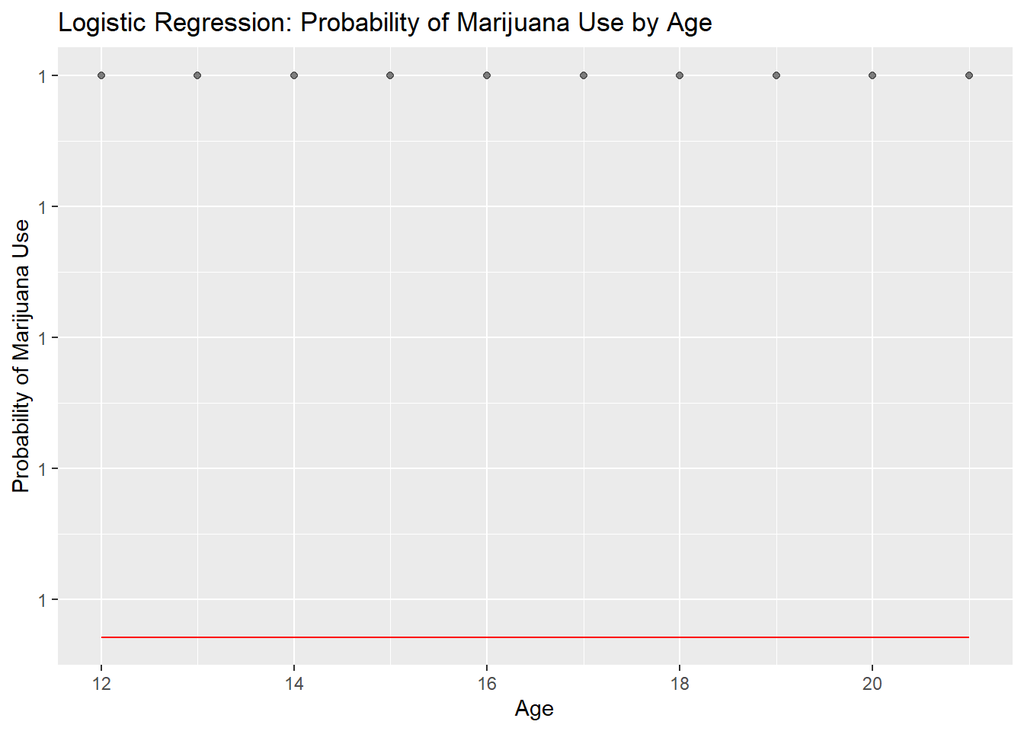

```r
# Check for finite min and max values of age
min_age <- min(clean_drug_data$age, na.rm = TRUE)
max_age <- max(clean_drug_data$age, na.rm = TRUE)

# Generate data for prediction
age_seq <- seq(min_age, max_age, by = 1)
pred_data <- data.frame(age = age_seq)
pred_data$predicted_prob <- predict(logistic_model, newdata = pred_data, type = "response")

# Plot the logistic regression curve
ggplot(clean_drug_data, aes(x = age, y = marijuana_use_binary)) +
  geom_point(alpha = 0.5) +
  geom_line(data = pred_data, aes(x = age, y = predicted_prob), color = "red") +
  labs(title = "Logistic Regression: Probability of Marijuana Use by Age",
       x = "Age",
       y = "Probability of Marijuana Use")
```

```r
# Convert age to numeric if necessary
drug_data$age <- as.numeric(as.character(drug_data$age))

# Remove rows with any NA, NaN, or Inf values
clean_drug_data <- drug_data %>%
  mutate(across(everything(), ~ifelse(is.nan(.), NA, .))) %>%
  filter_all(all_vars(!is.na(.))) %>%
  filter_all(all_vars(!is.infinite(.)))

# Verify the cleaned data
summary(clean_drug_data)
```

```
##       age              n         alcohol_use    alcohol_frequency
##  Min.   :12.00   Min.   :2223   Min.   : 3.90   Min.   : 3.0
##  1st Qu.:14.25   1st Qu.:2383   1st Qu.:20.88   1st Qu.: 6.0
##  Median :16.50   Median :2774   Median :44.70   Median :11.5
##  Mean   :16.50   Mean   :2672   Mean   :42.53   Mean   :20.3
##  3rd Qu.:18.75   3rd Qu.:2916   3rd Qu.:63.12   3rd Qu.:33.0
##  Max.   :21.00   Max.   :3058   Max.   :83.20   Max.   :52.0
##  marijuana_use   marijuana_frequency  cocaine_use    cocaine_frequency
##  Min.   : 1.10   Min.   : 4.00       Min.   :0.100   Length:10
##  1st Qu.:10.15   1st Qu.:24.25       1st Qu.:0.200   Class :character
##  Median :25.25   Median :33.00       Median :1.500   Mode  :character
##  Mean   :21.23   Mean   :35.80       Mean   :2.080
##  3rd Qu.:33.30   3rd Qu.:52.00       3rd Qu.:3.875
##  Max.   :34.00   Max.   :60.00       Max.   :4.900
##    crack_use     crack_frequency      heroin_use    heroin_frequency
##  Min.   :0.000   Length:10          Min.   :0.000   Length:10
##  1st Qu.:0.000   Class :character   1st Qu.:0.100   Class :character
##  Median :0.100   Mode  :character   Median :0.150   Mode  :character
##  Mean   :0.220                      Mean   :0.300
##  3rd Qu.:0.475                      3rd Qu.:0.475
##  Max.   :0.600                      Max.   :0.900
##  hallucinogen_use hallucinogen_frequency  inhalant_use   inhalant_frequency
##  Min.   :0.200    Min.   : 2.0           Min.   :1.400   Length:10
##  1st Qu.:1.725    1st Qu.: 3.0           1st Qu.:1.525   Class :character
##  Median :4.100    Median : 3.5           Median :1.900   Mode  :character
##  Mean   :4.200    Mean   : 8.4           Mean   :2.030
##  3rd Qu.:6.825    3rd Qu.: 4.0           3rd Qu.:2.500
##  Max.   :8.600    Max.   :52.0           Max.   :3.000
##  pain_releiver_use pain_releiver_frequency oxycontin_use   oxycontin_frequency
##  Min.   : 2.00     Min.   : 7.0            Min.   :0.100   Length:10
##  1st Qu.: 4.30     1st Qu.:10.0            1st Qu.:0.500   Class :character
##  Median : 7.35     Median :12.0            Median :1.200   Mode  :character
##  Mean   : 6.61     Mean   :13.7            Mean   :1.010
##  3rd Qu.: 9.15     3rd Qu.:13.5            3rd Qu.:1.475
##  Max.   :10.00     Max.   :36.0            Max.   :1.700
##  tranquilizer_use tranquilizer_frequency stimulant_use   stimulant_frequency
##  Min.   :0.200    Min.   : 4.50          Min.   :0.200   Min.   : 2.000
##  1st Qu.:1.175    1st Qu.: 5.50          1st Qu.:0.975   1st Qu.: 6.000
##  Median :2.950    Median : 8.50          Median :2.300   Median : 8.500
##  Mean   :2.770    Mean   :13.85          Mean   :2.180   Mean   : 7.850
##  3rd Qu.:4.125    3rd Qu.:11.75          3rd Qu.:3.225   3rd Qu.: 9.875
##  Max.   :5.400    Max.   :52.00          Max.   :4.100   Max.   :12.000
##     meth_use     meth_frequency      sedative_use  sedative_frequency
##  Min.   :0.000   Length:10          Min.   :0.10   Min.   : 3.000
##  1st Qu.:0.150   Class :character   1st Qu.:0.20   1st Qu.: 6.125
##  Median :0.350   Mode  :character   Median :0.30   Median : 9.500
##  Mean   :0.380                      Mean   :0.31   Mean   :11.700
##  3rd Qu.:0.575                      3rd Qu.:0.40   3rd Qu.:15.625
##  Max.   :0.900                      Max.   :0.50   Max.   :30.000
```

```r
# Fit a linear regression model for cocaine use
linear_model_cocaine <- lm(cocaine_use ~ age, data = clean_drug_data)

# Summary of the model
summary(linear_model_cocaine)
```

```
##
## Call:
## lm(formula = cocaine_use ~ age, data = clean_drug_data)
##
## Residuals:
##      Min       1Q   Median       3Q      Max
## -0.76182 -0.39591  0.01091  0.38364  0.88364
##
## Coefficients:
##             Estimate Std. Error t value Pr(>|t|)
## (Intercept) -8.42000    1.07258  -7.850  5.0e-05 ***
## age          0.63636    0.06404   9.937  8.9e-06 ***
## ---
## Signif. codes:  0 '***' 0.001 '**' 0.01 '*' 0.05 '.' 0.1 ' ' 1
##
## Residual standard error: 0.5817 on 8 degrees of freedom
## Multiple R-squared:  0.925,  Adjusted R-squared:  0.9157
## F-statistic: 98.74 on 1 and 8 DF,  p-value: 8.9e-06
```

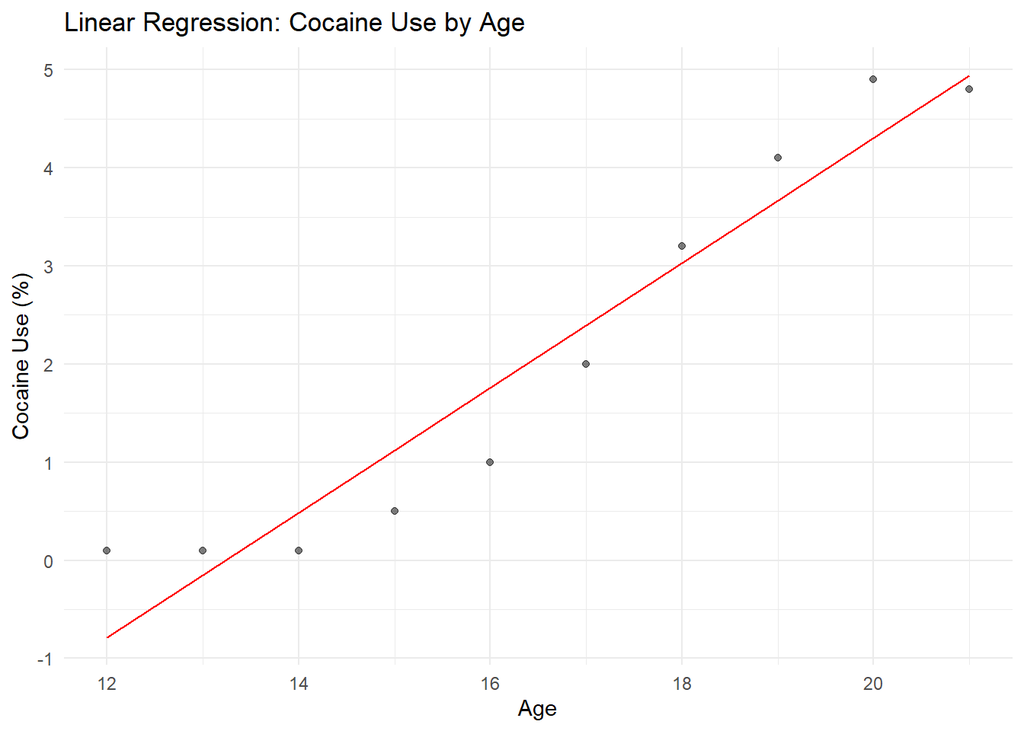

```r
# Generate predictions for the plot
clean_drug_data$predicted_cocaine_use <- predict(linear_model_cocaine, newdata = clean_drug_data)

# Plot the linear regression model
ggplot(clean_drug_data, aes(x = age, y = cocaine_use)) +
  geom_point(alpha = 0.5) +
  geom_line(aes(y = predicted_cocaine_use), color = "red") +
  labs(title = "Linear Regression: Cocaine Use by Age",
       x = "Age",
       y = "Cocaine Use (%)") +
  theme_minimal()
```

```r
# Fit a linear regression model for cocaine use
linear_model_alcohol <- lm(alcohol_use ~ age, data = clean_drug_data)

# Summary of the model
summary(linear_model_alcohol)
```

```
##
## Call:
## lm(formula = alcohol_use ~ age, data = clean_drug_data)
##
## Residuals:
##     Min      1Q  Median      3Q     Max
## -4.0606 -1.6512  0.2855  1.9045  2.7855
##
## Coefficients:
##              Estimate Std. Error t value Pr(>|t|)
## (Intercept) -104.7000     4.5491  -23.02 1.35e-08 ***
## age            8.9230     0.2716   32.85 8.04e-10 ***
## ---
## Signif. codes:  0 '***' 0.001 '**' 0.01 '*' 0.05 '.' 0.1 ' ' 1
##
## Residual standard error: 2.467 on 8 degrees of freedom
## Multiple R-squared:  0.9926, Adjusted R-squared:  0.9917
## F-statistic:  1079 on 1 and 8 DF,  p-value: 8.04e-10
```

[figure not shown]

```r
# Generate predictions for the plot
clean_drug_data$predicted_alcohol_use <- predict(linear_model_alcohol, newdata = clean_drug_data)

# Plot the linear regression model
ggplot(clean_drug_data, aes(x = age, y = cocaine_use)) +
  geom_point(alpha = 0.5) +
  geom_line(aes(y = predicted_alcohol_use), color = "red") +
  labs(title = "Linear Regression: Alcohol Use by Age",
       x = "Age",
       y = "Alcohol Use (%)") +
  theme_minimal()
```

```r
# Fit a linear regression model for cocaine use
linear_model_heroin <- lm(heroin_use ~ age, data = clean_drug_data)

# Summary of the model
summary(linear_model_heroin)
```

```
##
## Call:
## lm(formula = heroin_use ~ age, data = clean_drug_data)
##
## Residuals:
##       Min        1Q    Median        3Q       Max
## -0.240606 -0.054545 -0.009394  0.017121  0.315758
##
## Coefficients:
##             Estimate Std. Error t value Pr(>|t|)
## (Intercept) -1.04000    0.30290  -3.433  0.00891 **
## age          0.08121    0.01809   4.490  0.00203 **
## ---
## Signif. codes:  0 '***' 0.001 '**' 0.01 '*' 0.05 '.' 0.1 ' ' 1
##
## Residual standard error: 0.1643 on 8 degrees of freedom
## Multiple R-squared:  0.7159, Adjusted R-squared:  0.6804
## F-statistic: 20.16 on 1 and 8 DF,  p-value: 0.002028
```

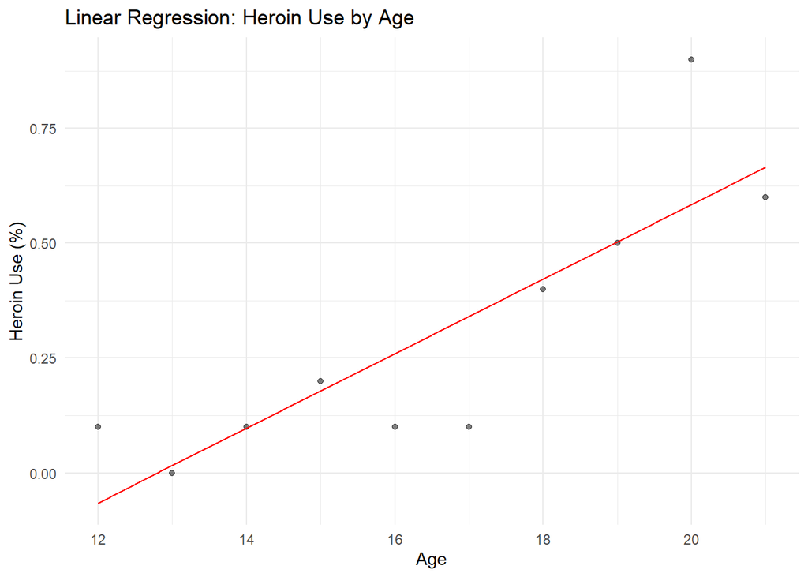

```r
# Generate predictions for the plot
clean_drug_data$predicted_heroin_use <- predict(linear_model_heroin, newdata = clean_drug_data)

# Plot the linear regression model
ggplot(clean_drug_data, aes(x = age, y = heroin_use)) +
  geom_point(alpha = 0.5) +
  geom_line(aes(y = predicted_heroin_use), color = "red") +
  labs(title = "Linear Regression: Heroin Use by Age",
       x = "Age",
       y = "Heroin Use (%)") +
  theme_minimal()
```

```r
# Fit a linear regression model for cocaine use
linear_model_crack <- lm(crack_use ~ age, data = clean_drug_data)

# Summary of the model
summary(linear_model_crack)
```

```
##
## Call:
## lm(formula = crack_use ~ age, data = clean_drug_data)
##
## Residuals:
##      Min       1Q   Median       3Q      Max
## -0.18303 -0.04833  0.01485  0.08864  0.12121
##
## Coefficients:
##             Estimate Std. Error t value Pr(>|t|)
## (Intercept) -1.00000    0.21122  -4.734 0.001474 **
## age          0.07394    0.01261   5.863 0.000377 ***
## ---
## Signif. codes:  0 '***' 0.001 '**' 0.01 '*' 0.05 '.' 0.1 ' ' 1
##
## Residual standard error: 0.1145 on 8 degrees of freedom
## Multiple R-squared:  0.8112, Adjusted R-squared:  0.7876
## F-statistic: 34.37 on 1 and 8 DF,  p-value: 0.0003772
```

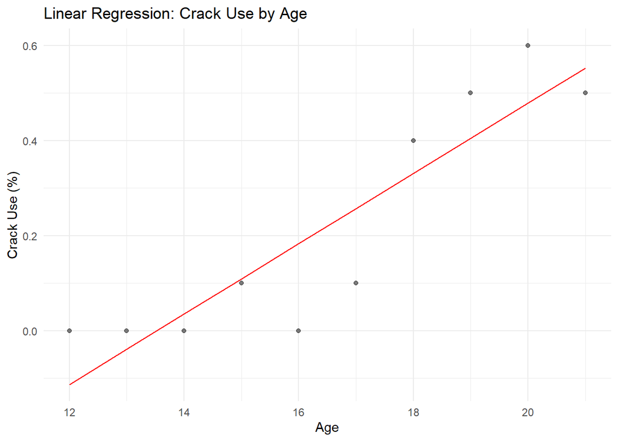

```r
# Generate predictions for the plot
clean_drug_data$predicted_crack_use <- predict(linear_model_crack, newdata = clean_drug_data)

# Plot the linear regression model
ggplot(clean_drug_data, aes(x = age, y = crack_use)) +
  geom_point(alpha = 0.5) +
  geom_line(aes(y = predicted_crack_use), color = "red") +
  labs(title = "Linear Regression: Crack Use by Age",
       x = "Age",
       y = "Crack Use (%)") +
  theme_minimal()
```

```r
# Fit linear regression models for each substance use
linear_model_crack <- lm(crack_use ~ age, data = clean_drug_data)
linear_model_alcohol <- lm(alcohol_use ~ age, data = clean_drug_data)
linear_model_heroin <- lm(heroin_use ~ age, data = clean_drug_data)
linear_model_marijuana <- lm(marijuana_use ~ age, data = clean_drug_data)
linear_model_sedative <- lm(sedative_use ~ age, data = clean_drug_data)
linear_model_painreliever <- lm(pain_releiver_use ~ age, data = clean_drug_data)
linear_model_inhalant <- lm(inhalant_use ~ age, data = clean_drug_data)

# Summarize each model
summary(linear_model_crack)
```

```
##
## Call:
## lm(formula = crack_use ~ age, data = clean_drug_data)
##
## Residuals:
##      Min       1Q   Median       3Q      Max
## -0.18303 -0.04833  0.01485  0.08864  0.12121
##
## Coefficients:
##             Estimate Std. Error t value Pr(>|t|)
## (Intercept) -1.00000    0.21122  -4.734 0.001474 **
## age          0.07394    0.01261   5.863 0.000377 ***
## ---
## Signif. codes:  0 '***' 0.001 '**' 0.01 '*' 0.05 '.' 0.1 ' ' 1
##
## Residual standard error: 0.1145 on 8 degrees of freedom
## Multiple R-squared:  0.8112, Adjusted R-squared:  0.7876
## F-statistic: 34.37 on 1 and 8 DF,  p-value: 0.0003772
```

```r
summary(linear_model_alcohol)
```

```
##
## Call:
## lm(formula = alcohol_use ~ age, data = clean_drug_data)
##
## Residuals:
##     Min      1Q  Median      3Q     Max
## -4.0606 -1.6512  0.2855  1.9045  2.7855
##
## Coefficients:
##              Estimate Std. Error t value Pr(>|t|)
## (Intercept) -104.7000     4.5491  -23.02 1.35e-08 ***
## age            8.9230     0.2716   32.85 8.04e-10 ***
## ---
## Signif. codes:  0 '***' 0.001 '**' 0.01 '*' 0.05 '.' 0.1 ' ' 1
##
## Residual standard error: 2.467 on 8 degrees of freedom
## Multiple R-squared:  0.9926, Adjusted R-squared:  0.9917
## F-statistic:  1079 on 1 and 8 DF,  p-value: 8.04e-10
```

```r
summary(linear_model_heroin)
```

```
##
## Call:
## lm(formula = heroin_use ~ age, data = clean_drug_data)
##
## Residuals:
##       Min        1Q    Median        3Q       Max
## -0.240606 -0.054545 -0.009394  0.017121  0.315758
##
## Coefficients:
##             Estimate Std. Error t value Pr(>|t|)
## (Intercept) -1.04000    0.30290  -3.433  0.00891 **
## age          0.08121    0.01809   4.490  0.00203 **
## ---
## Signif. codes:  0 '***' 0.001 '**' 0.01 '*' 0.05 '.' 0.1 ' ' 1
##
## Residual standard error: 0.1643 on 8 degrees of freedom
## Multiple R-squared:  0.7159, Adjusted R-squared:  0.6804
## F-statistic: 20.16 on 1 and 8 DF,  p-value: 0.002028
```

```r
summary(linear_model_marijuana)
```

```
##
## Call:
## lm(formula = marijuana_use ~ age, data = clean_drug_data)
##
## Residuals:
##     Min      1Q  Median      3Q     Max
## -6.9909 -2.0359 -0.9227  2.9527  6.2164
##
## Coefficients:
##             Estimate Std. Error t value Pr(>|t|)
## (Intercept) -47.5600     7.8264  -6.077 0.000297 ***
## age           4.1691     0.4673   8.922 1.98e-05 ***
## ---
## Signif. codes:  0 '***' 0.001 '**' 0.01 '*' 0.05 '.' 0.1 ' ' 1
##
## Residual standard error: 4.244 on 8 degrees of freedom
## Multiple R-squared:  0.9087, Adjusted R-squared:  0.8973
## F-statistic:  79.6 on 1 and 8 DF,  p-value: 1.976e-05
```

```r
summary(linear_model_sedative)
```

```
##
## Call:
## lm(formula = sedative_use ~ age, data = clean_drug_data)
##
## Residuals:
##      Min       1Q   Median       3Q      Max
## -0.13273 -0.09182 -0.01455  0.08318  0.17636
##
## Coefficients:
##             Estimate Std. Error t value Pr(>|t|)
## (Intercept) -0.14000    0.21388  -0.655   0.5311
## age          0.02727    0.01277   2.136   0.0652 .
## ---
## Signif. codes:  0 '***' 0.001 '**' 0.01 '*' 0.05 '.' 0.1 ' ' 1
##
## Residual standard error: 0.116 on 8 degrees of freedom
## Multiple R-squared:  0.3631, Adjusted R-squared:  0.2835
## F-statistic: 4.561 on 1 and 8 DF,  p-value: 0.06522
```

```r
summary(linear_model_painreliever)
```

```
##
## Call:
## lm(formula = pain_releiver_use ~ age, data = clean_drug_data)
##
## Residuals:
##      Min       1Q   Median       3Q      Max
## -1.89455 -0.32864  0.06182  0.38682  1.41394
##
## Coefficients:
##             Estimate Std. Error t value Pr(>|t|)
## (Intercept)  -9.1000     1.8668  -4.875  0.00123 **
## age           0.9521     0.1115   8.542 2.72e-05 ***
## ---
## Signif. codes:  0 '***' 0.001 '**' 0.01 '*' 0.05 '.' 0.1 ' ' 1
##
## Residual standard error: 1.012 on 8 degrees of freedom
## Multiple R-squared:  0.9012, Adjusted R-squared:  0.8888
## F-statistic: 72.97 on 1 and 8 DF,  p-value: 2.716e-05
```

```r
summary(linear_model_inhalant)
```

```
##
## Call:
## lm(formula = inhalant_use ~ age, data = clean_drug_data)
##
## Residuals:
##      Min       1Q   Median       3Q      Max
## -0.91818 -0.14818 -0.02152  0.24667  0.91576
##
## Coefficients:
##             Estimate Std. Error t value Pr(>|t|)
## (Intercept)  3.82000    0.93342   4.092  0.00347 **
## age         -0.10848    0.05573  -1.947  0.08746 .
## ---
## Signif. codes:  0 '***' 0.001 '**' 0.01 '*' 0.05 '.' 0.1 ' ' 1
##
## Residual standard error: 0.5062 on 8 degrees of freedom
## Multiple R-squared:  0.3214, Adjusted R-squared:  0.2366
## F-statistic: 3.789 on 1 and 8 DF,  p-value: 0.08746
```

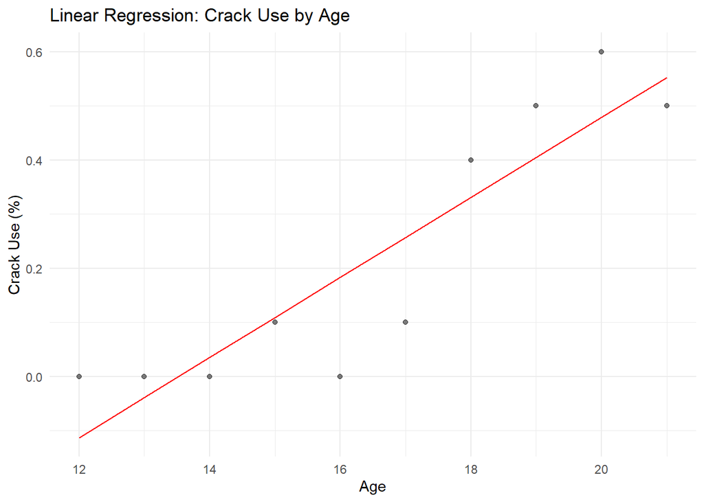

```r
# Generate predictions for the plots
clean_drug_data$predicted_crack_use <- predict(linear_model_crack, newdata = clean_drug_data)
clean_drug_data$predicted_alcohol_use <- predict(linear_model_alcohol, newdata = clean_drug_data)
clean_drug_data$predicted_heroin_use <- predict(linear_model_heroin, newdata = clean_drug_data)
clean_drug_data$predicted_marijuana_use <- predict(linear_model_marijuana, newdata = clean_drug_data)
clean_drug_data$predicted_sedative_use <- predict(linear_model_sedative, newdata = clean_drug_data)
clean_drug_data$predicted_painreliever_use <- predict(linear_model_painreliever, newdata = clean_drug_data)
clean_drug_data$predicted_inhalant_use <- predict(linear_model_inhalant, newdata = clean_drug_data)

# Plot the linear regression models
plot_crack <- ggplot(clean_drug_data, aes(x = age, y = crack_use)) +
  geom_point(alpha = 0.5) +
  geom_line(aes(y = predicted_crack_use), color = "red") +
  labs(title = "Linear Regression: Crack Use by Age",
       x = "Age",
       y = "Crack Use (%)") +
  theme_minimal()

plot_alcohol <- ggplot(clean_drug_data, aes(x = age, y = alcohol_use)) +
  geom_point(alpha = 0.5) +
  geom_line(aes(y = predicted_alcohol_use), color = "red") +
  labs(title = "Linear Regression: Alcohol Use by Age",
       x = "Age",
       y = "Alcohol Use (%)") +
  theme_minimal()

plot_heroin <- ggplot(clean_drug_data, aes(x = age, y = heroin_use)) +
  geom_point(alpha = 0.5) +
  geom_line(aes(y = predicted_heroin_use), color = "red") +
  labs(title = "Linear Regression: Heroin Use by Age",
       x = "Age",
       y = "Heroin Use (%)") +
  theme_minimal()

plot_marijuana <- ggplot(clean_drug_data, aes(x = age, y = marijuana_use)) +
  geom_point(alpha = 0.5) +
  geom_line(aes(y = predicted_heroin_use), color = "red") +
  labs(title = "Linear Regression: Marijuana Use by Age",
       x = "Age",
       y = "Marijuana Use (%)") +
  theme_minimal()

plot_sedative <- ggplot(clean_drug_data, aes(x = age, y = sedative_use)) +
  geom_point(alpha = 0.5) +
  geom_line(aes(y = predicted_sedative_use), color = "red") +
  labs(title = "Linear Regression: Sedative Use by Age",
       x = "Age",
       y = "Sedative Use (%)") +
  theme_minimal()

plot_painreliever <- ggplot(clean_drug_data, aes(x = age, y = pain_releiver_use)) +
  geom_point(alpha = 0.5) +
  geom_line(aes(y = predicted_painreliever_use), color = "red") +
  labs(title = "Linear Regression: Pain Reliever Use by Age",
       x = "Age",
       y = "Pain Reliever Use (%)") +
  theme_minimal()

plot_inhalant <- ggplot(clean_drug_data, aes(x = age, y = inhalant_use)) +
  geom_point(alpha = 0.5) +
  geom_line(aes(y = predicted_inhalant_use), color = "red") +
  labs(title = "Linear Regression: Inhalant Use by Age",
       x = "Age",
       y = "Inhalant Use (%)") +
  theme_minimal()

# Output the plots
plot_crack
```